# Capstone Project

This is a data visualization and manipulation part of our capstone project. The data is from AMC company.

### Loading the data into R notebook

```r
amcdata<-read.csv("C:/Users/jiena_000/Desktop/Capstone Project/AMCSampleData_InsiderPremier.csv", stringsAsFactors = F )
head(amcdata)
```

|  | ISPREMIER | AGE21PLUSINDICATOR | AGE18TO21INDICATOR | AGE13TO18INDICATOR | GENDERCODE | BIRTHDATE | AMCSTUBSLOYALTYEMAILOFFEROPTININDICATOR | AMCSTUBSREWARDSEMAILOPTININDICATOR | AMCSTUBSREWARDSMOBILEOPTININDICATOR | AMCSTUBSREWARDSSMSOPTININDICATOR | AMCSTUBSTHEATREMOBILEOFFEROPTININDICATOR | AMCSTUBSTHEATRESMSOFFEROPTININDICATOR | LIFETIMEAMCSTUBSAWARDSEARNEDAMOUNT | LIFETIMEAMCSTUBSSPENDAMOUNT | ONLINEFEESWAIVEDAMOUNT | ESTIMATEDINCOMERANGE | ESTIMATEDHOMEMARKETVALUERANGE | CHILDRENPRESENCE | HASFREQUENTVISITTHEATRENUMBER | TICKETQTYSUM | TICKETBALANCEDUESUM | CONCQTYSUM | CONCLOYDISCOUNTAMTSUM | CONCBALANCEDUESUM |
| --- | --- | --- | --- | --- | --- | --- | --- | --- | --- | --- | --- | --- | --- | --- | --- | --- | --- | --- | --- | --- | --- | --- | --- | --- |
| 1 | 1 | 1 | 0 | 0 | 3 | 1/13/1976 | 0 | 0 | 0 | 0 | 0 | 0 | 265 | 2706.45 | 61.25 | 0 | 0 | 3 | 1 | 51 | 969.09 | 7 | 0 | 41.71 |
| 2 | 1 | 1 | 0 | 0 | 1 | 7/6/1983 | 0 | 0 | 1 | 0 | 1 | 0 | 215 | 2113.36 | 123.00 | 3 | 13 | 0 | 0 | 40 | 842.00 | 1 | -1 | 7.49 |
| 3 | 1 | 1 | 0 | 0 | 3 | 10/20/1970 | 0 | 0 | 0 | 0 | 0 | 0 | 210 | 2141.80 | 182.50 | 0 | 0 | 3 | 1 | 49 | 675.66 | 4 | 0 | 25.42 |
| 4 | 0 | 1 | 0 | 0 | 0 | 7/10/1967 | 0 | 1 | 1 | 0 | 0 | 0 | 170 | 1749.20 | 47.75 | 9 | 13 | 1 | 1 | 38 | 616.61 | 72 | -7 | 474.14 |
| 5 | 1 | 1 | 0 | 0 | 1 | 8/1/1994 | 1 | 1 | 1 | 0 | 1 | 0 | 290 | 2822.35 | 45.00 | 8 | 6 | 3 | 1 | 47 | 607.53 | 10 | -2 | 63.60 |
| 6 | 1 | 1 | 0 | 0 | 3 | 1/12/1968 | 1 | 1 | 0 | 0 | 0 | 0 | 0 | 0.00 | 0.00 | 0 | 0 | 3 | 0 | 68 | 602.50 | 0 | 0 | 0.00 |

### Summary table of data

```r
summary(amcdata)
```

```
   ISPREMIER      AGE21PLUSINDICATOR AGE18TO21INDICATOR AGE13TO18INDICATOR
 Min.   :0.0000   Min.   :0.0000     Min.   :0.00000    Min.   :0.00000
 1st Qu.:0.0000   1st Qu.:1.0000     1st Qu.:0.00000    1st Qu.:0.00000
 Median :0.0000   Median :1.0000     Median :0.00000    Median :0.00000
 Mean   :0.1154   Mean   :0.8927     Mean   :0.06392    Mean   :0.03854
 3rd Qu.:0.0000   3rd Qu.:1.0000     3rd Qu.:0.00000    3rd Qu.:0.00000
 Max.   :1.0000   Max.   :1.0000     Max.   :1.00000    Max.   :1.00000

   GENDERCODE       BIRTHDATE     AMCSTUBSLOYALTYEMAILOFFEROPTININDICATOR
 Min.   :0.000   1/1/1990:   53   Min.   :0.0000
 1st Qu.:3.000   1/1/1980:   34   1st Qu.:1.0000
 Median :3.000   1/1/1970:   21   Median :1.0000
 Mean   :2.461   1/1/1999:   19   Mean   :0.8168
 3rd Qu.:3.000   1/1/2000:   16   3rd Qu.:1.0000
 Max.   :3.000   1/1/1971:   15   Max.   :1.0000
                 (Other) :47010
 AMCSTUBSREWARDSEMAILOPTININDICATOR AMCSTUBSREWARDSMOBILEOPTININDICATOR
 Min.   :0.0000                     Min.   :0.0000
 1st Qu.:1.0000                     1st Qu.:0.0000
 Median :1.0000                     Median :1.0000
 Mean   :0.8591                     Mean   :0.5031
 3rd Qu.:1.0000                     3rd Qu.:1.0000
 Max.   :1.0000                     Max.   :1.0000

 AMCSTUBSREWARDSSMSOPTININDICATOR AMCSTUBSTHEATREMOBILEOFFEROPTININDICATOR
 Min.   :0.00e+00                 Min.   :0.000
 1st Qu.:0.00e+00                 1st Qu.:0.000
 Median :0.00e+00                 Median :1.000
 Mean   :4.24e-05                 Mean   :0.508
 3rd Qu.:0.00e+00                 3rd Qu.:1.000
 Max.   :1.00e+00                 Max.   :1.000

 AMCSTUBSTHEATRESMSOFFEROPTININDICATOR LIFETIMEAMCSTUBSAWARDSEARNEDAMOUNT
 Min.   :0.00e+00                      Min.   :  0.000
 1st Qu.:0.00e+00                      1st Qu.:  0.000
 Median :0.00e+00                      Median :  0.000
 Mean   :4.24e-05                      Mean   :  4.878
 3rd Qu.:0.00e+00                      3rd Qu.:  0.000
 Max.   :1.00e+00                      Max.   :804.000

```

[output cut: 16 more lines]

```
  TICKETQTYSUM    TICKETBALANCEDUESUM   CONCQTYSUM     CONCLOYDISCOUNTAMTSUM
 Min.   : 0.000   Min.   :  0.00      Min.   : 0.000   Min.   :-17.6800
 1st Qu.: 0.000   1st Qu.:  0.00      1st Qu.: 0.000   1st Qu.:  0.0000
 Median : 1.000   Median :  7.98      Median : 0.000   Median :  0.0000
 Mean   : 2.283   Mean   : 22.92      Mean   : 1.968   Mean   : -0.1973
 3rd Qu.: 3.000   3rd Qu.: 30.78      3rd Qu.: 3.000   3rd Qu.:  0.0000
 Max.   :68.000   Max.   :969.09      Max.   :87.000   Max.   :  0.0000

 CONCBALANCEDUESUM
 Min.   :  0.00
 1st Qu.:  0.00
 Median :  0.00
 Mean   : 11.33
 3rd Qu.: 15.19
 Max.   :517.18
```

### Check the frequency table of “IsPremier”

```r
table(amcdata$ISPREMIER)
```

```
    0     1
41727  5441
```

Apparently, the data is imbalanced. Therefore, when we build a machine learning model, we have to check the AUC and ROC curve to have a better evaluation of models.

### Check the Gender code

```r
table(amcdata$GENDERCODE)
```

```
    0     1     3
 6012  3699 37457
```

- 0 is female
- 1 is male
- 3 is Unknown

### Correlation map

- Since the whole dataset has 24 variables, it might be too big to plot into one map. I classify them into four categories: biograph, notification, AMC stubs financial activities, Financial status and other AMC activities.

#### Correlation map of biograpic variables

Please note that I remove the gender is unknown data points.

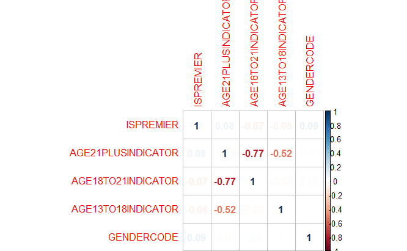

```r
library(corrplot)
 corrplot(cor(amcdata[,c(1:5)][which(amcdata$GENDERCODE!=3),]), method="number")
```

Obviously, “IsPremier” is not strongly related to any of biographic variables in this study.

### Notification variables

The notification variables include: * AMCSTUBSLOYALTYEMAILOFFEROPTININDICATOR - 0 is false; 1 is true * Opted in to receive AMC Loyalty program email offers. * AMCSTUBSREWARDSEMAILOPTININDICATOR - 0 is false; 1 is true * Opted in to receive AMC Stubs emails. * AMCSTUBSREWARDSMOBILEOPTININDICATOR - 0 is false; 1 is true * Opted in to receive AMC Stubs mobile notifications. * AMCSTUBSREWARDSSMSOPTININDICATOR - 0 is false; 1 is true * Opted in to receive AM Stubs SMS messages. * AMCSTUBSTHEATREMOBILEOFFEROPTININDICATOR - 0 is false; 1 is true * Opted in to receive AMC Stubs mobile theatre-level mobile offers. * AMCSTUBSTHEATRESMSOFFEROPTININDICATOR - 0 is false; 1 is true * Opted in to receive AMC Stubs theatre-level SMS offers.

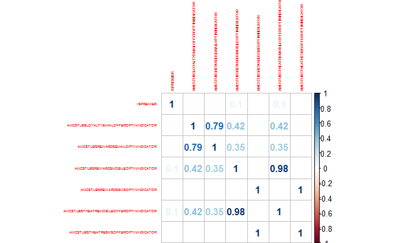

```r
library(corrplot)
 corrplot(cor(amcdata[,c(1,7,8,9,10,11,12)]), method="number",tl.cex = 0.4 )
```

Apparently, “IsPremier” is not strongly related to any notification variables.

### AMC stubs Member Financial Activities:

- LIFETIMEAMCSTUBSAWARDSEARNEDAMOUNT
- Amount of rewards in dollars that an AMC Stubs member has earned.
- LIFETIMEAMCSTUBSSPENDAMOUNT
- Amount of total spend by an AMC Stubs member.
- ONLINEFEESWAIVEDAMOUNT
- Amount of dollars in online ticketing fees waived as an AMC Stubs member.

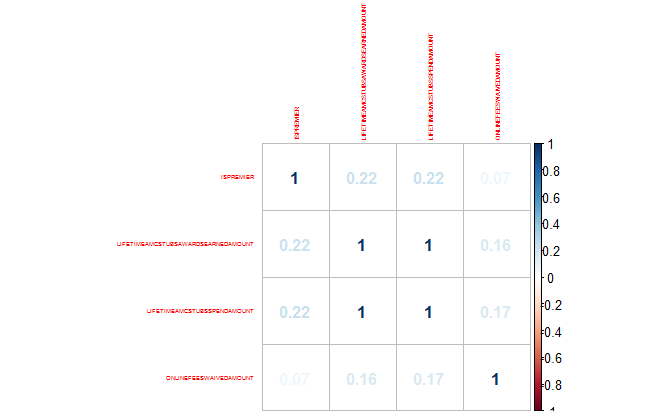

```r
library(corrplot)
 corrplot(cor(amcdata[,c(1,13,14,15)]), method="number",tl.cex = 0.4 )
```

If we consider the variables with correlation value about .2, then the “LIFETIMEAMCSTUBSAWARDSEARNEDAMOUNT” and “LIFETIMEAMCSTUBSSPENDAMOUNT” might be considered into modeling process.

### Financial Status and other AMC activities

- ESTIMATEDINCOMERANGE
- Axciom estimate of estimated income range for AMC Stubs member.
- ESTIMATEDHOMEMARKETVALUERANGE
- Axcion estimated home market value range for AMC Stubs member.
- CHILDRENPRESENCE - 0 is false; 1 is true
- Has children present in household.
- HASFREQUENTVISITTHEATRENUMBER - 0 is false; 1 is true
- Has a most frequently visited theatre selected through the site or by another means.
- TICKETQTYSUM
- Number of tickets sold to this AMC Stubs member.
- TICKETBALANCEDUESUM
- Total US dollar value of tickets sold to this AMC Stubs member.
- CONCQTYSUM
- Total number of concession items purchased by this AMC Stubs member.
- CONCLOYDISCOUNTAMTSUM
- Total amount of loyalty discount received by this AMC Stubs member (value in USD).
- CONCBALANCEDUESUM
- Total US dollar value of concessions sold to this AMC Stubs member.

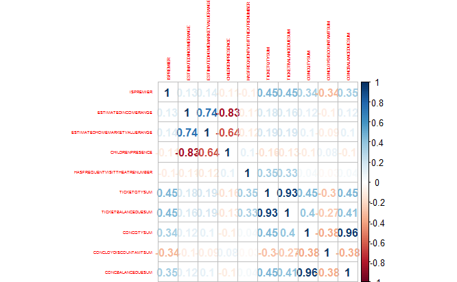

```r
library(corrplot)
 corrplot(cor(amcdata[,c(1,16,17,18,19,20,21,22,23,24)]), method="number",tl.cex = 0.4 )
```

From this result, we can see that “Is Premier” is strongly related (0.2 above) to “TICKETQTYSUM”, “TICKETBALANCEDUESUM”, “CONCQTYSUM”, “CONCLOYDISCOUNTAMTSUM” and “CONCBALANCEDUESUM”.

### Correlation test for “Is Premier” with strong variables

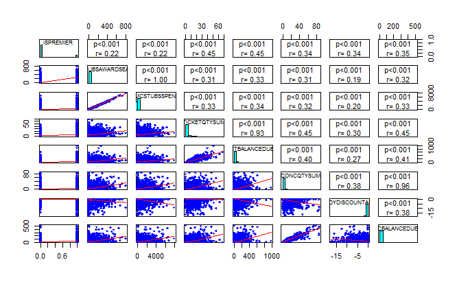

```r
panel.cor <- function(x, y, digits=2, cex.cor)
{
  usr <- par("usr"); on.exit(par(usr))
  par(usr = c(0, 1, 0, 1))
  r <- abs(cor(x, y))
  txt <- format(c(r, 0.123456789), digits=digits)[1]
  test <- cor.test(x,y)
  Signif <- ifelse(round(test$p.value,3)<0.001,"p<0.001",paste("p=",round(test$p.value,3)))
  text(0.5, 0.25, paste("r=",txt))
  text(.5, .75, Signif)
}
panel.smooth<-function (x, y, col = "blue", bg = NA, pch = 18,
                        cex = 0.8, col.smooth = "red", span = 2/3, iter = 3, ...)
{
  points(x, y, pch = pch, col = col, bg = bg, cex = cex)
  ok <- is.finite(x) & is.finite(y)
  if (any(ok))
    lines(stats::lowess(x[ok], y[ok], f = span, iter = iter),
          col = col.smooth, ...)
}
panel.hist <- function(x, ...)
{
  usr <- par("usr"); on.exit(par(usr))
  par(usr = c(usr[1:2], 0, 1.5) )
  h <- hist(x, plot = FALSE)
  breaks <- h$breaks; nB <- length(breaks)
  y <- h$counts; y <- y/max(y)
  rect(breaks[-nB], 0, breaks[-1], y, col="cyan", ...)
}
pairs(amcdata[,c(1,13,14,20,21,22,23,24)],
      lower.panel=panel.smooth, upper.panel=panel.cor,diag.panel=panel.hist)
```

From the p-value of this graph, we can see that “Is Premier” is significantly correlated with “LIFETIMEAMCSTUBSAWARDSEARNEDAMOUNT”, “LIFETIMEAMCSTUBSSPENDAMOUNT”, “TICKETQTYSUM”, “TICKETBALANCEDUESUM”, “CONCQTYSUM”, “CONCLOYDISCOUNTAMTSUM” and “CONCBALANCEDUESUM”. I will use these seven variables to predict the “Is Premier”.

## Predictive model 1: random forest

Step 1: select cols based on previous correlation map

```r
rfdata<-amcdata[,c(1,13,14,20,21,22,23,24)]
rfdata[1:3,]
```

|  | ISPREMIER | LIFETIMEAMCSTUBSAWARDSEARNEDAMOUNT | LIFETIMEAMCSTUBSSPENDAMOUNT | TICKETQTYSUM | TICKETBALANCEDUESUM | CONCQTYSUM | CONCLOYDISCOUNTAMTSUM | CONCBALANCEDUESUM |
| --- | --- | --- | --- | --- | --- | --- | --- | --- |
| 1 | 1 | 265 | 2706.45 | 51 | 969.09 | 7 | 0 | 41.71 |
| 2 | 1 | 215 | 2113.36 | 40 | 842.00 | 1 | -1 | 7.49 |
| 3 | 1 | 210 | 2141.80 | 49 | 675.66 | 4 | 0 | 25.42 |

Step 2: bar plot of “ISPREMIER”

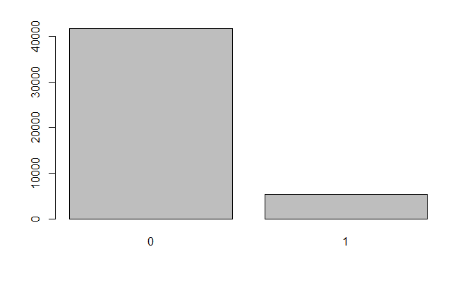

```r
barplot(table(rfdata$ISPREMIER ))
```

```r
rfdata$ISPREMIER<-as.factor(rfdata$ISPREMIER)
```

Step 3: set training and testing datasets

```r
set.seed(123)
samp <- sample(nrow(rfdata), 0.6 * nrow(rfdata))
train <- rfdata[samp, ]
test <- rfdata[-samp, ]
```

step 4: Model (random forest)

```r
library(randomForest)
model <- randomForest(ISPREMIER ~ . , data = train)
```

```r
model
```

```
Call:
 randomForest(formula = ISPREMIER ~ ., data = train)
               Type of random forest: classification
                     Number of trees: 500
No. of variables tried at each split: 2

        OOB estimate of  error rate: 6.14%
Confusion matrix:
      0    1 class.error
0 24746  281  0.01122787
1  1458 1815  0.44546288
```

Step 5: testing

```r
pred <- predict(model, newdata = test)
table(pred, test$ISPREMIER)
```

```
pred     0     1
   0 16517   957
   1   183  1211
```

Calculation of Random forest accuracy:

```r
(16517+1211) / nrow(test)
```

```
[1] 0.9395802
```

So, based on the random forest algorithm, the accuracy is 93.96%.

Step 6: features importance

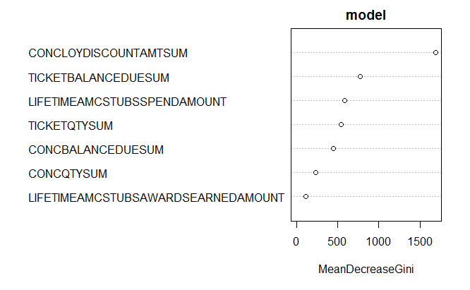

```r
gbmImp <- varImpPlot(model)
```

```r
gbmImp
```

```
                                   MeanDecreaseGini
LIFETIMEAMCSTUBSAWARDSEARNEDAMOUNT         109.5254
LIFETIMEAMCSTUBSSPENDAMOUNT                584.0738
TICKETQTYSUM                               539.7129
TICKETBALANCEDUESUM                        776.4180
CONCQTYSUM                                 232.6309
CONCLOYDISCOUNTAMTSUM                     1695.9146
CONCBALANCEDUESUM                          446.5474
```

## Decision Tree

```r
 library(rpart)
fit <- rpart(ISPREMIER ~ . , data = train,
               method="class")
fit
```

```
n= 28300

node), split, n, loss, yval, (yprob)
      * denotes terminal node

 1) root 28300 3273 0 (0.88434629 0.11565371)
   2) CONCLOYDISCOUNTAMTSUM>=-0.1 26326 1602 0 (0.93914761 0.06085239) *
   3) CONCLOYDISCOUNTAMTSUM< -0.1 1974  303 1 (0.15349544 0.84650456)
     6) CONCLOYDISCOUNTAMTSUM< -6.595 284   91 0 (0.67957746 0.32042254)
      12) CONCLOYDISCOUNTAMTSUM>=-8.495 219   31 0 (0.85844749 0.14155251) *
      13) CONCLOYDISCOUNTAMTSUM< -8.495 65    5 1 (0.07692308 0.92307692) *
     7) CONCLOYDISCOUNTAMTSUM>=-6.595 1690  110 1 (0.06508876 0.93491124) *
```

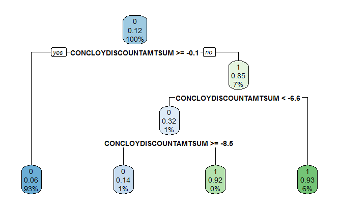

```r
library(rpart.plot)
    rpart.plot(fit)
```

```r
Prediction <- predict(fit, test, type = "class")
```

```r
table(Prediction, test$ISPREMIER)
```

```
Prediction     0     1
         0 16613  1084
         1    87  1084
```

Accuracy

```r
(16613+1084)/(16613+1084+1084+87)
```

```
[1] 0.9379372
```

## Clustering Analysis

### Hierarchical Agglomerative

Step 1: standardize variables

```r
mydata <- scale(rfdata[,-1]) # standardize variables
mydata[1:3,]
```

```
     LIFETIMEAMCSTUBSAWARDSEARNEDAMOUNT LIFETIMEAMCSTUBSSPENDAMOUNT TICKETQTYSUM TICKETBALANCEDUESUM
[1,]                           8.444389                    9.032002    12.747752            23.87914
[2,]                           6.821232                    7.014080     9.869406            20.67168
[3,]                           6.658916                    7.110844    12.224416            16.47365
     CONCQTYSUM CONCLOYDISCOUNTAMTSUM CONCBALANCEDUESUM
[1,]  1.1823354             0.1942739         1.2742988
[2,] -0.2275180            -0.7904887        -0.1608643
[3,]  0.4774087             0.1942739         0.5911075
```

Step 2: Modeling

```
Clustering k = 1,2,..., K.max (= 10): .. done
Bootstrapping, b = 1,2,..., B (= 100)  [one "." per sample]:
.................................................. 50
.................................................. 100
```

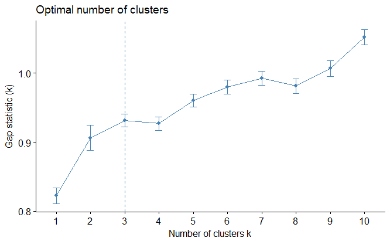

```r
library("cluster")
library("factoextra")
library("factoextra")
fviz_nbclust(mydata[1:500,], kmeans, method = "gap_stat")
```

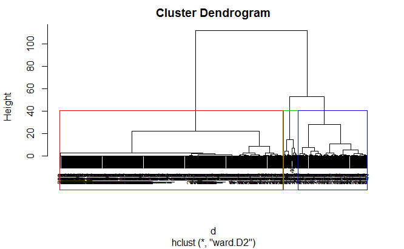

```r
library("factoextra")
d <- dist(mydata[1:500], method = "euclidean")
# Hierarchical clustering using Ward's method
res.hc <- hclust(d, method = "ward.D2" )
# Cut tree into 4 groups
grp <- cutree(res.hc, k = 3)
# Visualize
plot(res.hc, cex = 0.6) # plot tree
rect.hclust(res.hc, k = 3, border = 2:5) # add rectangle
```